# assign2

## Assignment 2 - More Tidyverse and Preparing for Linear Regression

The deliverable for this assignment is a rendered HTML document. Submit your document via Canvas.

For all questions where a comment or an answer is required, be sure to type out the answer. Do not depend on the R code and output to “speak for you”. For example, if asked how many rows are in a dataset, do not just use a structure command and assume that the answer will be seen. Instead, please write out: “There are ___ rows”.

We will use the “mpg” dataset that is found in the ggplot2 package. This dataset is described here: https://ggplot2.tidyverse.org/reference/mpg.html. The ggplot2 package is part of the Tidyverse, so it is available to us after we install and library the tidyverse package. Note that this is a different dataset than the “mtcars” dataset that we looked at in class.

Install the tidyverse, gridExtra, GGally, and esquisse packages as necessary. Once installed, you will need to library them by running the code chunk below.

```r
# install.packages("tidyverse")
# install.packages("gridExtra")
# install.packages("GGally")
#install.packages("esquisse")
library(tidyverse)
library(gridExtra) #for arranging charts in a grid
library(GGally) #for producing correlation plots
library(esquisse)
```

Begin by reading in the dataset for this assignment from the ggplot2 package. Use the code below.

```r
mpg = ggplot2::mpg
```

**Q1** How many rows and columns are in this dataset?

- There are 234 rows and 11 columns.

**Q2** Convert the “trans”, “drv”, “fl”, and “class” variables to factors. You do not need to rename the levels of the factors. Use the summary or str command to verify that you have correctly performed the conversion.

```r
mpg_con = mpg %>% mutate_if(is.character, as_factor)
```

```r
str(mpg_con)
```

```
tibble [234 × 11] (S3: tbl_df/tbl/data.frame)
 $ manufacturer: Factor w/ 15 levels "audi","chevrolet",..: 1 1 1 1 1 1 1 1 1 1 ...
 $ model       : Factor w/ 38 levels "a4","a4 quattro",..: 1 1 1 1 1 1 1 2 2 2 ...
 $ displ       : num [1:234] 1.8 1.8 2 2 2.8 2.8 3.1 1.8 1.8 2 ...
 $ year        : int [1:234] 1999 1999 2008 2008 1999 1999 2008 1999 1999 2008 ...
 $ cyl         : int [1:234] 4 4 4 4 6 6 6 4 4 4 ...
 $ trans       : Factor w/ 10 levels "auto(l5)","manual(m5)",..: 1 2 3 4 1 2 4 2 1 3 ...
 $ drv         : Factor w/ 3 levels "f","4","r": 1 1 1 1 1 1 1 2 2 2 ...
 $ cty         : int [1:234] 18 21 20 21 16 18 18 18 16 20 ...
 $ hwy         : int [1:234] 29 29 31 30 26 26 27 26 25 28 ...
 $ fl          : Factor w/ 5 levels "p","r","e","d",..: 1 1 1 1 1 1 1 1 1 1 ...
 $ class       : Factor w/ 7 levels "compact","midsize",..: 1 1 1 1 1 1 1 1 1 1 ...
```

**Q3** Plot the relationship between “displ” (displacement is a representation of engine size) and “hwy” (vehicle fuel efficiency in miles per gallon for highway driving). Describe this relationship. Note that you should place “displ” on the x axis as it would be used a predictor to predict hwy. In other words, “displ” likely has a causal relationship with “hwy”.

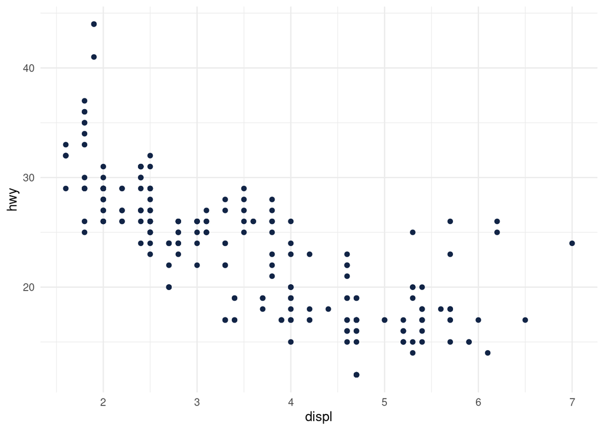

```r
#esquisser
library(ggplot2)

ggplot(mpg_con) +
 aes(x = displ, y = hwy) +
 geom_point(colour = "#112446") +
 theme_minimal()
```

- Based on the scatter plot I can make the statement that as the displacement increases the hwy mpg will decrease on average. It is not a perfect negative linear relationship but it does follow that general trend.

**Q4** Choose an appropriate visualization and plot the relationship between “class” and “hwy”. Describe this relationship.

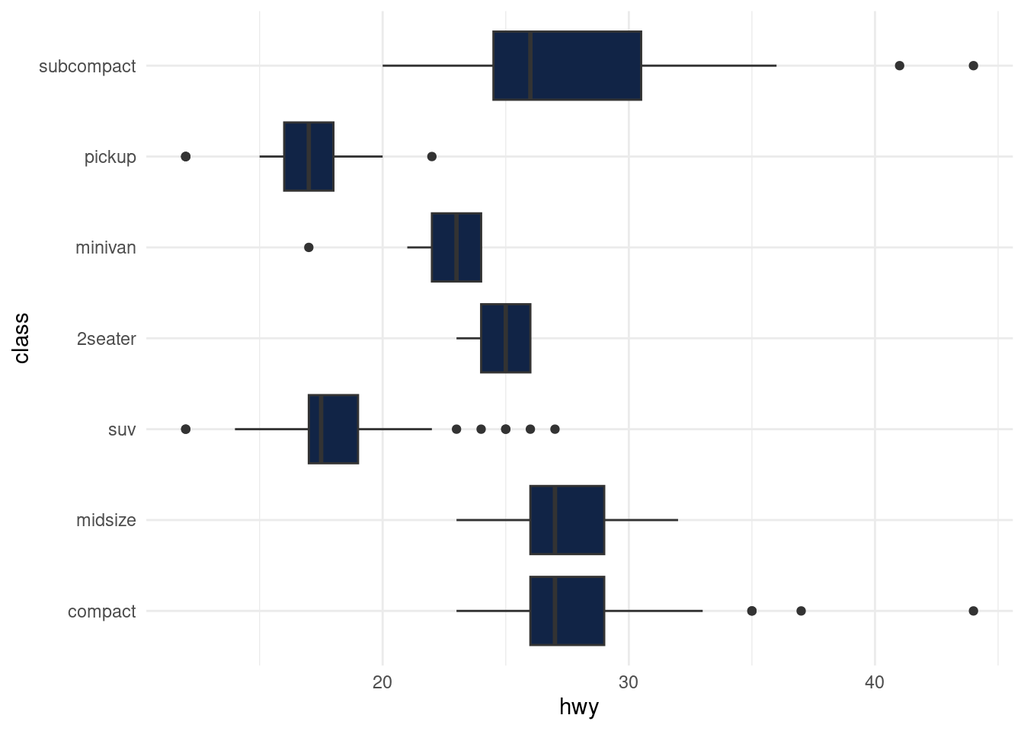

```r
#esquisser()

library(ggplot2)

ggplot(mpg_con) +
 aes(x = hwy, y = class) +
 geom_boxplot(fill = "#112446") +
 theme_minimal()
```

**Q5** Choose an appropriate visualization and plot the distribution of “hwy”. Comment on this distribution.

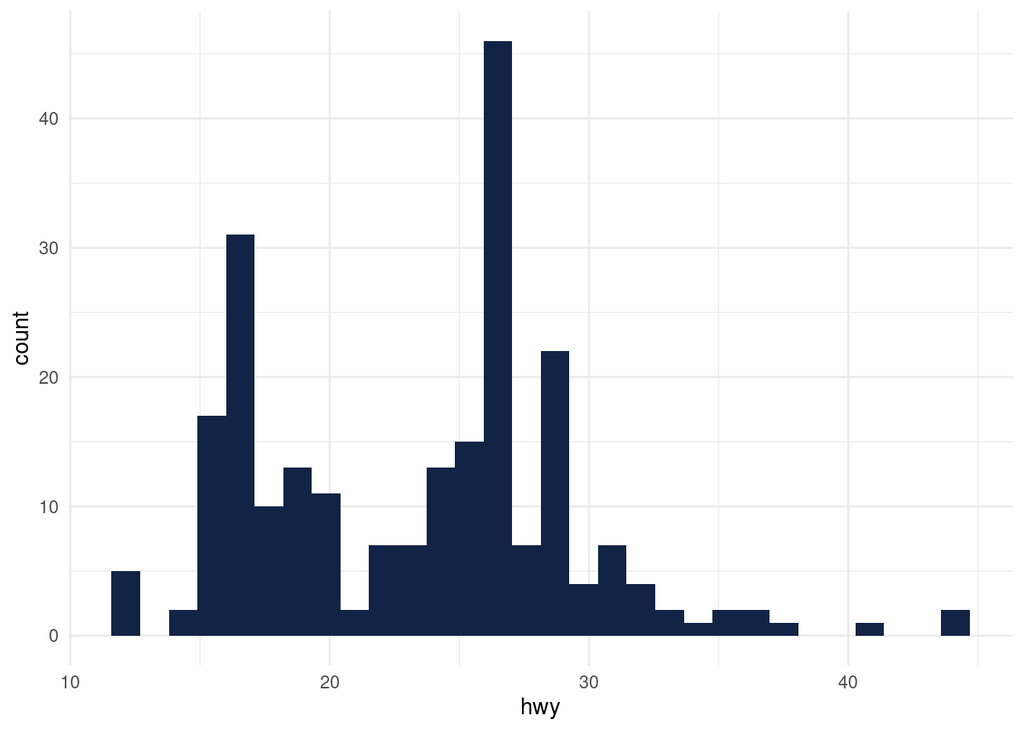

```r
#esquisser()

library(ggplot2)

ggplot(mpg_con) +
 aes(x = hwy) +
 geom_histogram(bins = 30L, fill = "#112446") +
 theme_minimal()
```

- From the distribution I can see that hwy mileage is most common at around 16 and 26 mpg with the majority from 16 to 29 mpg.

**Q6** We use correlation to examine the strength of linear relationships between variables. Two variables that are strongly correlated with each other will have correlations close to either 1 (strongly positive) or -1 (strongly negative). Correlation values are only calculated (in any way that makes sense) for numeric variables.

Use the line of code below to create a correlation matrix for the numeric variables in this dataset. Note that ggcorr is from the GGally package.

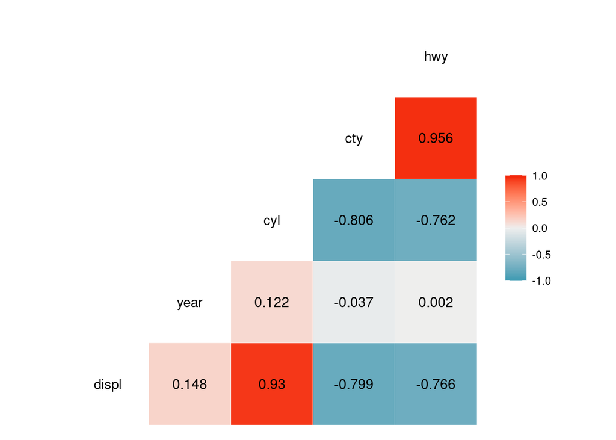

```r
ggcorr(mpg_con,label = TRUE, label_round = 3)
```

Which variable is most strongly correlated with “hwy”? Which variable is the second most strongly correlated with “hwy”?

- The most correlated with hwy is cty and the second most correlated is displ.

**Q7** You can develop a plot that shows a plot for each combination of variables as well as the correlations using the ggpairs function. Note that ggpairs is from the GGally package.

Use the code below to develop a ggpairs plot for this dataset. Note that I have listed the columns in the dataset that I want to see in the plot rather than including all columns. The ggpairs plot can easily become too cluttered if you include too many variables. Columns must be specified by column number. To avoid clutter, I have created two separate plots. Both plots include the variable of interest (hwy) that is in column nine. The plots are still a bit messy. The only required output for this question is the two plots.

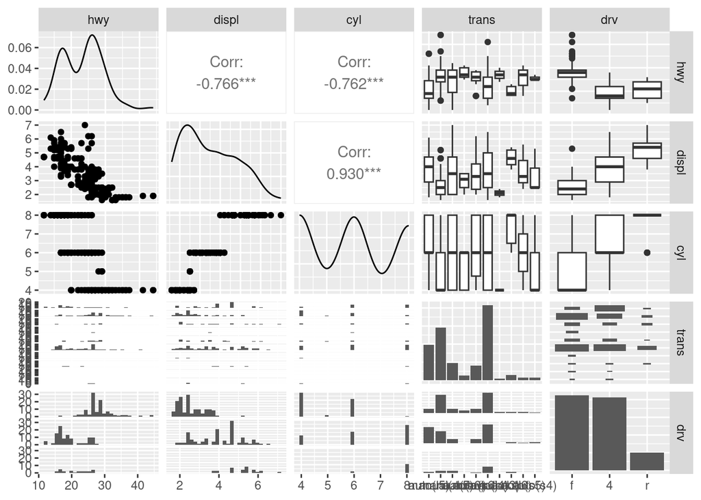

```r
ggpairs(mpg_con, columns = c(9,3,5:7))
```

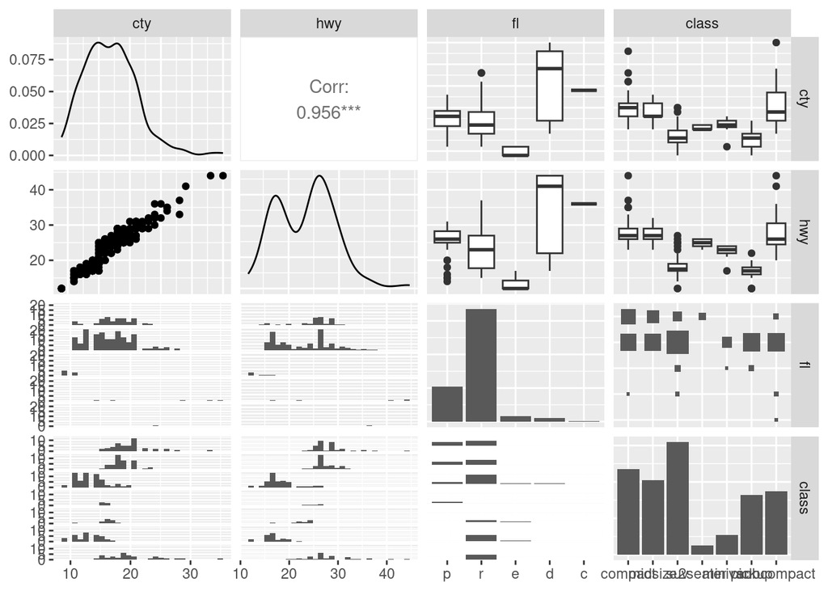

```r
ggpairs(mpg_con, columns = c(8:11))
```